**Course**: Data Visualization (Prof. Dr. Heike Leitte, Luisa Vollmer, RPTU Kaiserslautern), **Name**: XXX XXX, **Date**: DD.MM.YYYY

# Assignment 5 - Graphs

### Outline and goals

In the fifth assignment, we will revise graph drawing and graph analysis using three types of graphs. You will learn about the [networkx library](https://networkx.github.io) and the [pygraphviz library](https://pygraphviz.github.io) for graph analysis and drawing. The goals of the assignment are:

- be able to decide on an appropriate layout for a given graph and discuss aesthetics criteria
- draw a graph in the notebook and manipulate the visualization
- analyze a given graph algorithmicly and visually

**Important**: While no points will be awarded for typing the correct answers in the notebooks, it is highly advised to solve the tasks thoroughly. They are designed to be encouraging and provide you with valuable learnings for the exam, understanding of the methods and practical coding.

All tasks in this notebook are marked in green.

```python
import pandas as pd
import numpy as np

import networkx as nx # there have been problems with networkx and pygraphviz on windows in the past. If possible, try a different system.
import itertools
from bokeh.palettes import Category20

from IPython.display import Image
```

## Exercise 1 - Graph algorithms recap

In the first exercise, you will work on a synthetic graph to practice fundamental operations and revise the concepts from the lecture.

**1.1 Manual drawing**

G1 below is defined as a directed graph [nx.DiGraph](https://networkx.github.io/documentation/stable/reference/classes/digraph.html). Edges are given as ordered tuples `(start_node, end_node)`.

- Draw the graph defined in G1 manually (no prove required). Do not follow the rules learned in class, but create a layout to your liking.
- Did you follow aesthetics criteria? If yes, which? Either case, which ones should be followed.
- Which type of graph is G1?
- Which types of layouts are applicable?

I drew and I followed some aesthetics criteria, such as minimum cross between edges and same distance between nodes with the same distance. Anyway, the criteria that shuold be followed is:

1. Edges point in a uniform direction.
2. Edges are as short as possible.
3. Nodes are uniformly distributed.
4. Edge crossings are minimize.
5. Edges are as straight as possible

G1 is a directed graph.

The DOT layout is applicable.

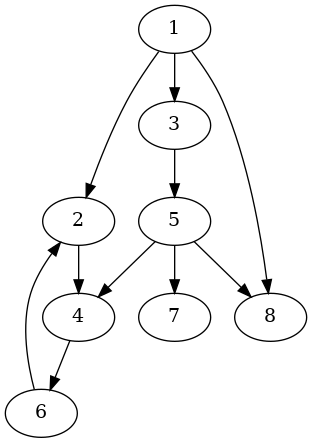

```python
G1 = nx.DiGraph()
G1.add_edges_from([(1,2), (1,3), (2,4), (3,5), (5,4), (4,6), (6,2), (5,7), (5,8), (1,8)])
Image(nx.nx_agraph.to_agraph(G1).draw(format='png', prog='dot'))
```

**1.2 Graph drawing**

The [pygraphviz library](https://pygraphviz.github.io) is used to obtain the layout. Pygraphviz is partly integrated into networkx and uses the [AGraph](http://pygraphviz.github.io/documentation/pygraphviz-1.5/reference/agraph.html) graph representation. The result image of the graph drawing routine can be exported or rendered in the notebook using the [`Image`](https://ipython.readthedocs.io/en/stable/api/generated/IPython.display.html#IPython.display.Image) class to encapsulate it.

Using the graph drawing above, answer the following questions:

- Which layout algorithm is used to render G1?
- Does the graph G1 contain cycles? If yes, which?
- Why is node 2 rendered on level 3?
- Compute the forward, backward and cross edges of G1. Children are handeled in order of their id, smallest first. The method `classify_edges` below implements the edge classification for recap.

The layout algorithm is the DOT one.

Yes, the cycle is within the nodes 2,4 and 6.

Node 2 is rendered on level 3 because of the "Leveling" formula, !(u,v) ∈ E ω(u, v)(λ(v) − λ(u)), which is used to minimize the edges sizes.

1 2 tree edge 2 4 tree edge 4 6 tree edge 6 2 backward edge 1 3 tree edge 3 5 tree edge 5 4 cross edge 5 7 tree edge 5 8 tree edge 1 8 forward edge

```python
def classify_edges(G):
    '''Edge classification of a directed graph using depth first search.
    '''
    # nodes that have been visited in the traversal
    marked = dict([(n,0) for n in sorted(G.nodes)])

    # do depth-first-traversal and classify edges
    # traverse edges with (start, end, edge type d)
    for s,e,d in nx.dfs_labeled_edges(G):
        if (s==e):
            continue

        # mark start-node as visited
        marked[s] = 1

        # skip return-to-child-node step in DFS
        if  (d == 'reverse'):
            continue

        # if end-node has not been visited yet, its a tree edge
        if marked[e] == 0:
            print(s,e,'tree edge')
            marked[e] = 1
        # end-node has been visited before
        else:
            # create graph without current edge
            G_ = G.copy()
            G_.remove_edge(s,e)
            if e in nx.descendants(G_, s):
                print(s,e,'forward edge')
            elif e in nx.ancestors(G_, s):
                print(s,e,'backward edge')
            else:
                print(s,e,'cross edge')

classify_edges(G1)
```

```
1 2 tree edge
2 4 tree edge
4 6 tree edge
6 2 backward edge
1 3 tree edge
3 5 tree edge
5 4 cross edge
5 7 tree edge
5 8 tree edge
1 8 forward edge
```

## Exercise 2 - Working with hierarchies

The file `programmingLanguages.gml` contains information on the genealogy of some of the more influential or widely used programming languages as discussed by (Scott, 2000). Edges indicate principal influences on design. The resulting graph encodes the flow of ideas through the languages and their paradigms. Many influences, of course, cannot be shown in a single figure, but the chart can give a good initial sense of dependencies.

Note that the graph also contains a date for each language which indicates the approximate time at which its features became widely known. This information can be used for rendering but is not incorporated in the current layout.

```python
G2 = nx.read_gml("programmingLanguages.gml")

print("nodes in the graph", G2.nodes(data=True))
print()

language = 'Simula'
print(language, "became widely known in", G2.nodes[language]['year'])
```

```
nodes in the graph [('Fortran I', {'year': 1957}), ('Fortran II', {'year': 1958}), ('Fortran IV', {'year': 1965}), ('Fortran 77', {'year': 1978}), ('Fortran 90', {'year': 1991}), ('Algol 58', {'year': 1958}), ('Basic', {'year': 1964}), ('Visual Basic', {'year': 1991}), ('Fortran 95', {'year': 1997})…

Simula became widely known in 1965
```

The chart below displays the programming languages graph. Answer the following questions and give a graphical answer by coloring respective nodes.

- **Initial languages**: Which languages were not influenced by others?
- **Long history**: Which language has the longest history, i.e., the longest path to a source node?
  - What is the path length?
  - Is the answer unique?
- **Not influenced by Fortran I**: List all languages that were not influenced by Fortran I (directly or indirectly).

**Example below**: All languages that influenced Java directly or indirectly.

**Hints**:

- Networkx provides [methods for directed graphs](https://networkx.github.io/documentation/stable/reference/classes/digraph.html) (see Method section at bottom of page) and
- additional [algorithms for directed acyclic graphs](https://networkx.github.io/documentation/stable/reference/algorithms/dag.html).
- Each question can be answered with one line of code.

```
=-=-=-=-=-=-=-=-=-=-=-=-=-=-=-=-=-=-=-=-=-=-=-=-=-=-=-=-=-=-=-=-=-=
The longest path is in blue and has 8 nodes.
We have 4 programming language that were not influenced by others. They are painted on green(except Fortran I, that still in blue)
```

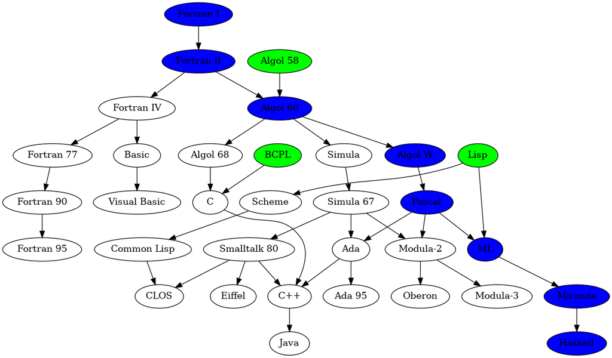

```python
A2 = nx.nx_agraph.to_agraph(G2)
A2.node_attr['style']='filled'

influences = nx.algorithms.dag.ancestors(G2,'Java')
not_influenced = [node for node, in_degree in G2.in_degree() if in_degree == 0]

longest_path = nx.algorithms.dag.dag_longest_path(G2)
longest_path_value = nx.algorithms.dag.dag_longest_path_length(G2)
print('=-=-=-=-=-=-=-=-=-=-=-=-=-=-=-=-=-=-=-=-=-=-=-=-=-=-=-=-=-=-=-=-=-=')
print('The longest path is in blue and has', longest_path_value+1, 'nodes.')
print('We have',len(not_influenced),'programming language that were not influenced by others. They are painted on green(except Fortran I, that still in blue)')

for n_id in G2:
    n = A2.get_node(n_id)
    if n_id in longest_path:
        n.attr['fillcolor']='blue'
    elif n_id in not_influenced:
        n.attr['fillcolor']='green'
    else:
        n.attr['fillcolor']='white'

Image(A2.draw(format='png', prog='dot'))
```

```
=-=-=-=-=-=-=-=-=-=-=-=-=-=-=-=-=-=-=-=-=-=-=-=-=-=-=-=-=-=-=-=-=-=
6 programming languages were not influenced by Fortran I
```

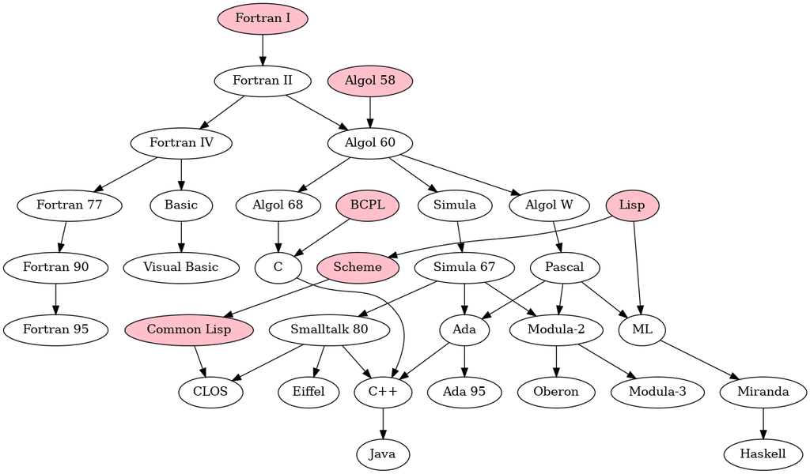

```python
A2 = nx.nx_agraph.to_agraph(G2)
A2.node_attr['style']='filled'

influenced_by_fortran_1 = nx.algorithms.dag.descendants(G2,'Fortran I')
print('=-=-=-=-=-=-=-=-=-=-=-=-=-=-=-=-=-=-=-=-=-=-=-=-=-=-=-=-=-=-=-=-=-=')
print(len(G2.nodes) - len(influenced_by_fortran_1), 'programming languages were not influenced by Fortran I')

for n_id in G2:
    n = A2.get_node(n_id)
    if n_id not in influenced_by_fortran_1:
        n.attr['fillcolor']='pink'
    else:
        n.attr['fillcolor']='white'

Image(A2.draw(format='png', prog='dot'))
```

## Exercise 3 - Analyzing social networks

In the last exercise, you will analyze social networks. Choose ***ONE*** of two datasets each representing a co-appearance network:

- characters in the novel Les Miserables by Victor Hugo and how often they are together on stage (edges)
- characters in fan fiction in the Harry Potter universe and a count on how often they occur together in fan fictions (edges)

A critical element in the analysis are communities. A community in a graph is a set of nodes that is densely connected, i.e., many of the nodes in a community feature pairwise edges.

The graphs below represent the respective co-occurences. Both graphs are drawn using the [`neato`](https://www.graphviz.org/pdf/neatoguide.pdf) algorithm of pygraphviz which uses a force-directed layout. Communitites are detected using the [Girvan-Newman community detection algorithm](https://networkx.github.io/documentation/stable/reference/algorithms/generated/networkx.algorithms.community.centrality.girvan_newman.html) from networkx. Each community is colored in a unique color in the graph.

For your chosen social network, answer the following questions:

- What are aesthetics criteria aimed for by force-directed layout?
- How good are these criteria met in the graph visualization? Rate each criterion using good, medium, poor and find an area in the graph to support your rating.
- Below you can find a list of social groups present in the novel. Check if they are detected by the automatic community detection. When do the communities based on human knowledge and graph analysis match and when not?
- Can you detect characters that should belong to multiple communities?
  - by exploring the graph structure and maybe from your background knowledge
  - Advanced question: How could you visualize the affiliation with two or more communities?

The aesthetics criteria aimed by the force-directed layout are:

- Short & uniform edge lengths
- Symmetry; uniform distribution of children
- Minimize edge crossings
- Minimize edges crossing nodes
- Compact layout

Rating in the graph:

- Short & uniform edge lengths = medium
- Symmetry; uniform distribution of children = poor
- Minimize edge crossings = medium
- Minimize edges crossing nodes = medium
- Compact layout = poor

I would analyze how much edges are going to the directions of differents communities.

### Les Miserables

The dataset `lesmiserables.gml` contains a coappearance network of characters in the novel [Les Miserables](https://en.wikipedia.org/wiki/Les_Mis%C3%A9rables) by Victor Hugo. The graph is rendered using a force-directed layout and colored by a community affiliation detected using the [Girvan-Newman community detection algorithm](https://networkx.github.io/documentation/stable/reference/algorithms/generated/networkx.algorithms.community.centrality.girvan_newman.html).

*Data courtesy: D. E. Knuth, The Stanford GraphBase: A Platform for Combinatorial Computing, Addison-Wesley, Reading, MA (1993).*

```python
G3 = nx.read_gml("lesmiserables.gml")
A3 = nx.nx_agraph.to_agraph(G3)
A3.node_attr['style']='filled'


### I concatenated a string marker at the end of each name to make easy to find them in the plot

# church + police NOT
# Javert, Bamatabois, Champmathieu, Myriel, MlleBaptistine, MmeMagloire

# grisettes+ wealthy students YESS
# Gillenormand, MlleGillenormand, MmePontmercy, LtGillenormand, Blacheville, Tholomyes, Listolier, Fameuil


# Wealthy students + Monarchists NOT
# test_nodes = ["Gillenormand","MlleGillenormand","MmePontmercy","LtGillenormand", "Blacheville", "Tholomyes", "Listolier", "Fameuil"]

# Bandits + Police and court NOT
# MmeThenardier, Thenardier, (Cosette), (Gavroche), Eponine, Anzelma, Montparnasse, Claquesous, Babet, Gueulemer, Brujon, Javert, Bamatabois, Champmathieu

test_nodes = ["MmeThenardier", "Thenardier", "Cosette", "Gavroche", "Eponine", "Anzelma", "Montparnasse", "Claquesous", "Babet", "Gueulemer", "Brujon", "Javert", "Bamatabois", "Champmathieu"]

for node_name in test_nodes:
    node = A3.get_node(node_name)
    if node is not None:
        current_label = node.attr['label']
        node.attr['label'] = f'{current_label}_____________________'


for e in A3.edges_iter():
    '''Scale the line_width of the edges by the edge weight
    '''
    e.attr['penwidth'] = int(int(e.attr['value'])/5)*2+1

def color_communities(G,A,k=9):
    comp = nx.algorithms.community.centrality.girvan_newman(G)
    comm = next(itertools.islice(comp, k, None))
    print("quality {:.3f}".format(nx.algorithms.community.partition_quality(G,comm)[1]), "with", len(comm), "communities.")

    def color_nodes(A, communities):
        '''Color the nodes of an AGraph based on a given community structure
        '''
        for ids,c in zip(list(sorted(c) for c in communities), Category20[20]):
            for i in ids:
                n = A.get_node(i)
                n.attr['fillcolor']=c

    color_nodes(A, comm)

color_communities(G3, A3, 9)
```

```
quality 0.918 with 11 communities.
```

A [list of characters](https://en.wikipedia.org/wiki/List_of_Les_Mis%C3%A9rables_characters) can be found on wikipedia.

Communitites in Les Miserables in order of appearance:

- **Main characters**: Valjean, Cosette, Marius
- **People in church**: Myriel, MlleBaptistine, MmeMagloire
- **Grisettes (working women)**: Fantine, Zephine, Dahlia, Favourite
- **Wealthy students**: Blacheville, Tholomyes, Listolier, Fameuil
- **Bandits + (family)**: MmeThenardier, Thenardier, (Cosette), (Gavroche), Eponine, Anzelma, Montparnasse, Claquesous, Babet, Gueulemer, Brujon
- **Police and court**: Javert, Bamatabois, Champmathieu
- **Rich monarchists**: Gillenormand, MlleGillenormand, MmePontmercy, LtGillenormand
- **Revolutionary student club**: Marius, Enjolras, Combeferre, Prouvaire, Feuilly, Courfeyrac, Bahorel, Bossuet, Joly, Grantaire
- **Brothers**: Gavroche, Child1, Child2

```python
# Show image in notebook
Image(A3.draw(format='png', prog='neato', args="-Goverlap=scale -Gsize=20,15 -Gepsilon=.001 -Gmaxiter=50"))

# Export image
A3.draw('lesmiserables_graph.png', format='png', prog='neato', args="-Goverlap=scale -Gsize=50,50 -Gepsilon=.001 -Gmaxiter=50")

# You can control the size of the image with the graph parameter -Gsize
```

[output not shown]

### Harrry Potter fan fiction

The Harry Potter fan fiction dataset contains a co-appearance network of characters in the Harry Potter fan fiction universe. The graph is rendered using a force-directed layout and colored by a community affiliation detected using the [Girvan-Newman community detection algorithm](https://networkx.github.io/documentation/stable/reference/algorithms/generated/networkx.algorithms.community.centrality.girvan_newman.html).

*Data source: https://gist.github.com/allisonking/c9f6ea277e4194cf7e13f49efb83b5b5*

**Preprocessing**:

Load the Harry Potter fan fiction co-occurence data and turn this into a list of co-occurences.

```python
harry_potter = pd.read_csv('HarryPotter_cooccurrence.txt')

# get the upper triangular matrix and turn into a list
harry_potter = harry_potter.where(np.triu(np.ones(harry_potter.shape), k=1).astype(bool)).stack().reset_index()
# rename the columns
harry_potter.columns = ['A','B','cnt']
# filter character pairs that co-occur at least 300 times
harry_potter = harry_potter[harry_potter.cnt >= 300].reset_index(drop=True)
```

Create a graph from the input data.

```python
G4 = nx.Graph()

r = harry_potter.apply(lambda x: G4.add_edge(x.A, x.B, weight=x.cnt), axis=1)

# remove the meta group of original characters (OC)
G4.remove_node('OC')

A4 = nx.nx_agraph.to_agraph(G4)
A4.node_attr['style']='filled'

for e in A4.edges_iter():
    '''Scale the line_width of the edges by the edge weight
    '''
    e.attr['penwidth'] = min(10000,float(e.attr['weight']))/1000+1

def color_communities(G,A,k=11):
    comp = nx.algorithms.community.centrality.girvan_newman(G)
    comm = next(itertools.islice(comp, k, None))
    print("quality {:.3f}".format(nx.algorithms.community.partition_quality(G,comm)[1]), "with", len(comm), "communities.")

    def color_nodes(A, communities):
        '''Color the nodes of an AGraph based on a given community structure
        '''
        for ids,c in zip(list(sorted(c) for c in communities), Category20[20]):
            for i in ids:
                n = A.get_node(i)
                n.attr['fillcolor']=c

    color_nodes(A, comm)

color_communities(G4, A4, 11)
```

```
quality 0.871 with 14 communities.
```

Communitites in the Harry Potter universe:

- **Students**: Harry P., Ron W., Hermione G., Ginny W., Draco M., Neville L., Luna L., Pansy P., Blaise Z., Cedric D., Cho C.
- **Senior students**: Katie B., Oliver W., Percy W., George W., Fred W.
- **Teachers**: Albus D., Severus S., Minerva M.
- **Death Eaters**: Voldemort, Tom R. Jr., Lucius M., Narcissa M., Bellatrix L.
- **Marauders**: Marauders, James P., Sirius B., Remus L., Peter P.
- **Next generation kids**: Lily Luna P., James S. P., Albus S. P., Rose L., Teddy L., Scorpius M., Victoire W.

Additional communities

- the various families: Potter, Weasly, Malfoy, Black, Tonks, Lestrange, ...
- Order of the Phoenix
- school houses and school teams

[figure not shown]

```python
# Show image in notebook
Image(A4.draw(format='png', prog='neato', args="-Goverlap=scale -Gsize=15,15 -Gepsilon=.001 -Gmaxiter=50"))

# Export image
# A4.draw('harrypotter_graph.png', format='png', prog='neato', args="-Goverlap=scale -Gsize=50,50 -Gepsilon=.001 -Gmaxiter=50")

# You can control the size of the image with the graph parameter -Gsize
```

### Estimate good number of communities in graph

First do the community detection for the parameters (0,k):

```python
k=30
G = G4

comp = nx.algorithms.community.centrality.girvan_newman(G)
limited = itertools.takewhile(lambda c: len(c) <= k, comp)
ks = []
qs = []
for i,communities in enumerate(limited):
    ks.append(i)
    qs.append(nx.algorithms.community.partition_quality(G,communities)[1])
```

Plot these values and look for the "knee" or "elbow" in the function, i.e., the value where the curve "bends" and additional communities have little quality increase.

```python
from bokeh.plotting import figure, output_notebook, show

output_notebook()

p = figure(width=400, height=400, title="Quality of GN-Community Measure in Harry Potter")

# add a line renderer
p.line(ks, qs, line_width=2)
p.xaxis.axis_label = 'Girvan Newman splitting parameter'
p.yaxis.axis_label = 'quality'

show(p)
```

[output not shown]

Loading BokehJS ...